# PSTAT131-HW2

Jiashu Huang

2022-10-10

### Question 1

Assess and describe the distribution of `age`.

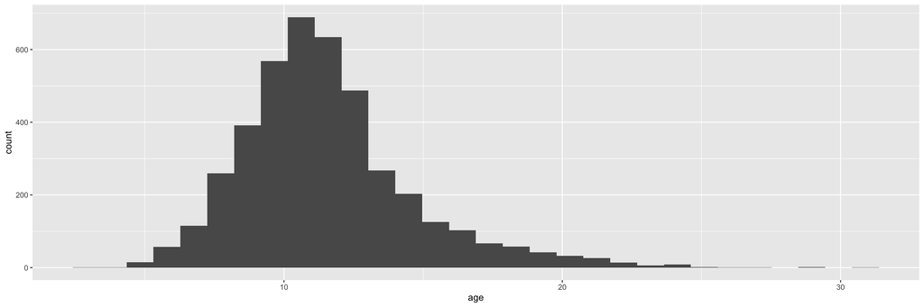

```r
options(readr.show_col_types = FALSE)
abalone=read_csv("data/abalone.csv")
abalone$age <- abalone$rings + 1.5
ggplot(abalone,aes(age))+
  geom_histogram()
```

The distribution of age is slightly positively skewed. It has a peak at age = 11.

### Question 2

```r
set.seed(1234)
data_split <- initial_split(abalone, prop = 4/5, strata = age)
data_train <- training(data_split)
data_test <- testing(data_split)
```

*Remember that you’ll need to set a seed at the beginning of the document to reproduce your results.*

### Question 3

Steps for your recipe:

1. dummy code any categorical predictors
2. create interactions between
   - `type` and `shucked_weight`,
   - `longest_shell` and `diameter`,
   - `shucked_weight` and `shell_weight`
3. center all predictors, and
4. scale all predictors.

```r
some_var <- names(data_train)[9]
aba_recipe <- recipe(formula = age~., data = data_train) %>%
  step_rm(some_var) %>%
  step_dummy(all_nominal_predictors()) %>%
  step_interact(terms = ~ starts_with('type'):shucked_weight) %>%
  step_interact(terms = ~ longest_shell:diameter) %>%
  step_interact(terms = ~ shucked_weight:shell_weight) %>%
  step_center(all_numeric_predictors()) %>%
  step_scale(all_numeric_predictors()) %>%
  prep()
```

### Question 4

Create and store a linear regression object using the `"lm"` engine.

```r
lm_model <- linear_reg() %>%
  set_engine("lm")
```

### Question 5

1. set up an empty workflow,
2. add the model you created in Question 4, and
3. add the recipe that you created in Question 3.

```r
workflow <- workflow() %>%
  add_model(lm_model) %>%
  add_recipe(aba_recipe)
```

### Question 6

Use your `fit()` object to predict the age of a hypothetical female abalone with longest_shell = 0.50, diameter = 0.10, height = 0.30, whole_weight = 4, shucked_weight = 1, viscera_weight = 2, shell_weight = 1.

```r
model <- fit(workflow,data_train)
newdata <- data.frame(type="F",longest_shell=0.50, diameter=0.10, height=0.30, whole_weight=4, shucked_weight=1, viscera_weight = 2, shell_weight=1, rings=0)
pre <- predict(model, new_data=newdata)
cat("The predicted age of the abalone is ", unlist(pre[1]), ".", sep="")
```

```
## The predicted age of the abalone is 23.48823.
```

### Question 7

1. Create a metric set that includes *R<sup>2</sup>*, RMSE (root mean squared error), and MAE (mean absolute error).
2. Use `predict()` and `bind_cols()` to create a tibble of your model’s predicted values from the **training data** along with the actual observed ages (these are needed to assess your model’s performance).
3. Finally, apply your metric set to the tibble, report the results, and interpret the *R<sup>2</sup>* value.

```r
data_train_pred <- predict(model, new_data = data_train %>% select(-age))
data_train_pred <- bind_cols(data_train_pred, data_train %>% select(age))
metrics <- metric_set(rsq, rmse, mae)
metrics(data_train_pred, truth = age, estimate = .pred)
```

```
## # A tibble: 3 × 3
##   .metric .estimator .estimate
##   <chr>   <chr>          <dbl>
## 1 rsq     standard       0.558
## 2 rmse    standard       2.15
## 3 mae     standard       1.55
```

By evaluating the model, we get a rmse value fo 2.15, r-square value of 0.56, and a mae value of 1.54. From rmse, we know that the average distance between the observation and the prediction is about 2.15 years. However, since the model only has a r-square of 0.56, only around 56% of the variance in age could be explained by the predictor variables in the model. It is clear that the performance of the model is not that well.

### Required for 231 Students

#### Question 8

$[Bias(\hat{f}(x_0))]^2$ and $Var(\hat{f}(x_0))$ represent reproducible errors. $Var(\epsilon)$ represents the irreducible error. Even if we have the real f(), it is still impossible to get rid of $Var(\epsilon)$.

#### Question 10

Prove the bias-variance trade-off.

$$\begin{align}
E[(y_0 -
\hat{f}(x_0))^2]&=E[(f(x_0)+\epsilon-E[\hat{f}(x_0)]+E[\hat{f}(x_0)]-\hat{f}(x_0))^2]\\
&=E[(f(x_0)-E[\hat{f}(x_0)]+\epsilon)^2]+E[(E[\hat{f}(x_0)]-\hat{f}(x_0))^2]+2E[(f(x_0)-\hat{f}(x_0)+\epsilon)(E[\hat{f}(x_0)]-\hat{f}(x_0))]\\
\end{align}$$
The first term
$$\begin{align}
E[(f(x_0)-E[\hat{f}(x_0)]+\epsilon)^2]&=E[(f(x_0)-E[\hat{f}(x_0)])^2]+2E[\epsilon(f(x_0)-E[\hat{f}(x_0)])]+E[\epsilon^2]\\
&=E[f(x_0)^2]-2E[f(x_0)E[\hat{f}(x_0)]]+E[E[\hat{f}(x_0)]^2]+2(f(x_0)-E[\hat{f}(x_0)])E[\epsilon]+E[\epsilon^2]\\
&=E[f(x_0)^2]-2f(x_0)E[\hat{f}(x_0)]+E[\hat{f}(x_0)]^2+0+E[\epsilon^2]
\end{align}$$
Notice $E[f(x_0)^2]=E[f(x_0)]^2+Var(f(x_0))=E[f(x_0)]^2=f(x_0)^2$ and $E[\epsilon^2]=E[\epsilon]^2+Var(\epsilon)=Var(\epsilon)$
The first term then becomes
$$\begin{align}
E[f(x_0)^2]-2f(x_0)E[\hat{f}(x_0)]+E[\hat{f}(x_0)]^2+0+E[\epsilon^2]&=f(x_0)^2-2f(x_0)E[\hat{f}(x_0)]+E[\hat{f}(x_0)]^2+Var(\epsilon)\\
&=(f(x_0)-E[\hat{f}(x_0)])^2+Var(\epsilon)\\
&=[Bias(\hat{f}(x_0))]^2+Var(\epsilon)
\end{align}$$
The second term is, by the definition of variance,
$$\begin{align}
E[(E[\hat{f}(x_0)]-\hat{f}(x_0))^2] = Var(\hat{f}(x_0))
\end{align}$$
The third term is
$$\begin{align}
2E[(f(x_0)-\hat{f}(x_0)+\epsilon)(E[\hat{f}(x_0)]-\hat{f}(x_0))]
&=2E[((f(x_0)-\hat{f}(x_0))(E[\hat{f}(x_0)]-\hat{f}(x_0))]+2E[\epsilon(E[\hat{f}(x_0)]-\hat{f}(x_0))]\\
&=2((f(x_0)-\hat{f}(x_0))E[(E[\hat{f}(x_0)]-\hat{f}(x_0)]+2E[\epsilon]E[E[\hat{f}(x_0)]-\hat{f}(x_0)]\\
&=2((f(x_0)-\hat{f}(x_0))(E[\hat{f}(x_0)]-E[\hat{f}(x_0)])+2\times
0E[E[\hat{f}(x_0)]-\hat{f}(x_0)]\\
&=0+0=0
\end{align}$$
Combining three terms, we get
$$\begin{align}
E[(y_0 - \hat{f}(x_0))^2] =
[Bias(\hat{f}(x_0))]^2+Var(\hat{f}(x_0))+Var(\epsilon)
\end{align}$$